# APS Finanças 2 - Seleção de Portfolio

### Grupo: Guilherme Silvarolli Aliperti e Nicolas Stegmann

## O teorema de Markowitz

Se pedirmos a investidores para descreverem o processo de investimento, reduzido a sua essência, a maioria dirá que consiste em escolher bons ativos dentro do universo de ativos. Por “bons ativos”, geralmente se entende ativos com capacidade de gerar retornos positivos ou boas perspectivas de valorização, associado a baixo risco de perda.

O risco é geralmente definido com desvio padrão dos retornos. Dessa forma, o investidor atuaria como um observador de ativos, procurando o melhor os ativos com maior retorno em relação ao seu risco. Essa ótica porém está incompleta, pois ignora a relação entre ativos. As inter-relações de ativos, quantificadas estatisticamente como covariâncias, podem ser exploradas para melhorar o risco-retorno do investidor.

Assim entra em ação o teorema de Markowitz. Utilizando as propriedades de distribuições normais multivariadas, Harry Markowitz propos que o investidor pode atingir retornos melhores do que seriam obtidos com ativos individualmente.

Dessa forma, o trabalho aqui proposto tem como objetivo a aplicação do teorema de Markowitz para se definir a carteira ótima de investimento de risco compostas por 10 ativos diferentes.

## A implementação

### Primeira etapa

A primeira etapa do trabalho foi a criação de uma base de dados mostrando os resultados de de diversas ações de risco listadas na bolsa. Nessa etapa, os dados foram resgatados no Economática e o resultado da pesquisa de todos os grupos gerou uma base de dados que será utilizada no resto do projeto.

Utilizamos a LTN (Título do tesouro pré-fixado) com vencimento em julho de 2021 como nossa proxy para ativo livre de risco.

```python
import pandas as pd
import matplotlib.pyplot as plt
from pypfopt import EfficientFrontier
from pypfopt import risk_models
from pypfopt import expected_returns
from pypfopt import plotting
from pypfopt import CLA
from pypfopt import *

rf = 0.0227 #rf usado como referencia em todos os calculos
df = pd.read_csv("dados/grupo2.csv", parse_dates=True, index_col="Data")
df.head()
```

| Data | MELI | AMZN | APPL | MSFT | CRM | LREN3 | RENT3 | VVAR3 | WEGE3 | RADL3 | IBOV |
| --- | --- | --- | --- | --- | --- | --- | --- | --- | --- | --- | --- |
| Jan-10 | 36.85 | 125.41 | 5.93 | 22.12 | 15.89 | 4.71 | 4.71 | 3.05 | 4.18 | 8.10 | 65401 |
| Fev-10 | 39.87 | 118.40 | 6.32 | 22.61 | 16.99 | 5.11 | 4.70 | 2.52 | 4.14 | 8.34 | 66503 |
| Mar-10 | 46.72 | 135.77 | 7.25 | 23.10 | 18.61 | 5.34 | 4.49 | 3.07 | 4.47 | 8.60 | 70371 |
| Abr-10 | 48.86 | 137.10 | 8.06 | 24.08 | 21.40 | 5.74 | 4.66 | 2.91 | 4.17 | 9.03 | 67529 |
| Mai-10 | 50.26 | 125.46 | 7.93 | 20.44 | 21.63 | 5.81 | 4.58 | 3.00 | 4.00 | 8.91 | 63046 |

### Segunda etapa

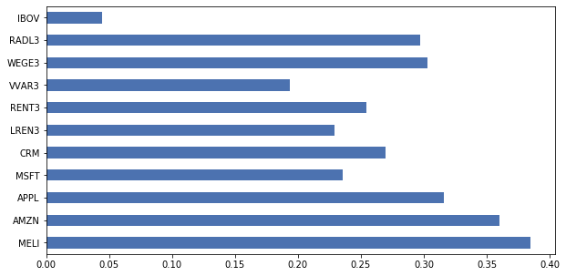

```python
mu = expected_returns.mean_historical_return(df, frequency= 12)
mu.plot.barh(figsize=(10,5));
```

Utilizando esses mesmos dados, calculamos a matriz de covariância da carteira, representada no gráfico abaixo:

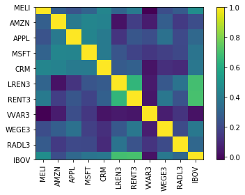

```python
S = risk_models.sample_cov(df)
plotting.plot_covariance(S, plot_correlation=True)
```

Feito isso, utilizamos um solver disponível na biblioteca citada anteriormente para calcular os pesos de cada ativo na carteira de risco ótima. Os pesos e Tickers de cada ativo são salvos em um documento .csv. Além disso podemos analisar o retorno esperado, volatilidade e indice de Sharpe da carteira.

```python
ef = EfficientFrontier(mu, S)
raw_weights = ef.max_sharpe()
cleaned_weights = ef.clean_weights()
ef.save_weights_to_file("weights.csv")
r = ef.portfolio_performance(verbose=True, risk_free_rate = rf)
```

```
Expected annual return: 30.2%
Annual volatility: 78.2%
Sharpe Ratio: 0.36
```

Abaixo podemos observar os pesos gravados no arquivo de saída.

```python
df = pd.read_csv("weights.csv")
df
```

|  | MELI | 0.03087 |
| --- | --- | --- |
| 0 | AMZN | 0.19903 |
| 1 | APPL | 0.13680 |
| 2 | MSFT | 0.12590 |
| 3 | CRM | 0.07948 |
| 4 | LREN3 | 0.05384 |
| 5 | RENT3 | 0.00000 |
| 6 | VVAR3 | 0.00000 |
| 7 | WEGE3 | 0.18701 |
| 8 | RADL3 | 0.18707 |
| 9 | IBOV | 0.00000 |

Utilizando as funções abaixo, podemos observar o gráfico com a fronteira eficiente de investimento e a carteira ótima de risco, que maximiza o indice de Sharpe.

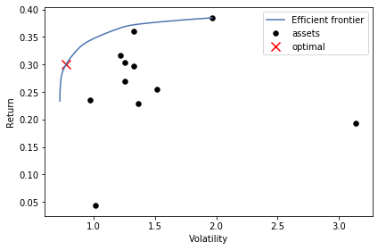

```python
cla = CLA(mu, S)
cla.max_sharpe()
cla.portfolio_performance()
ax = plotting.plot_efficient_frontier(cla)
```

### Terceira etapa

O mesmo algoritmo foi replicado para o cálculo da carteira ótima dos outro grupos. O trecho de código abaixo calcula as 10 carteiras ótimas e compara o Sharpe de cada uma, retornando a mais eficiente. Como pode ser observado abaixo, a carteira selecionada foi a do grupo 3.

```python
max_sharpe = 0
for i in range(1,11):
    path = "dados/grupo" + str(i) + ".csv"
    df = pd.read_csv(path, parse_dates=True, index_col="Data")
    mu = expected_returns.mean_historical_return(df, frequency= 12)
    S = risk_models.sample_cov(df)

    # Otimiza melhor Sharpe
    ef = EfficientFrontier(mu, S)
    raw_weights = ef.max_sharpe()
    cleaned_weights = ef.clean_weights()
    retorno = ef.portfolio_performance(risk_free_rate = rf)

    if retorno[2] > max_sharpe:
        max_sharpe = retorno[2]
        port = path
        ef.save_weights_to_file("weights.csv")

print("Sharpe da Carteira Ótima Selecionada: {0}".format(max_sharpe))
print(port)
```

```
Sharpe da Carteira Ótima Selecionada: 0.4750919788239898
dados/grupo3.csv
```

Seguem os pesos da carteira selecionada:

```python
df_weights = pd.read_csv("weights.csv")
df_weights
```

|  | GOOGL | 0.10488 |
| --- | --- | --- |
| 0 | B3SA3 | 0.00000 |
| 1 | BBAS3 | 0.00000 |
| 2 | ITSA4 | 0.00000 |
| 3 | RENT3 | 0.00926 |
| 4 | VVAR3 | 0.00000 |
| 5 | OZ1D | 0.18956 |
| 6 | VALE3 | 0.00000 |
| 7 | FLMA11 | 0.04224 |
| 8 | RADL3 | 0.03325 |
| 9 | NTN-F | 0.62082 |

Retornos esperados de cada ativo para essa carteira

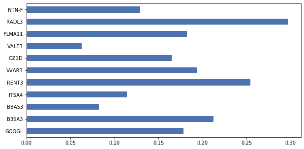

```python
df = pd.read_csv(port, parse_dates=True, index_col="Data")
mu = expected_returns.mean_historical_return(df, frequency = 12)
mu.plot.barh(figsize=(10,5));
```

Matriz de covariância da carteira:

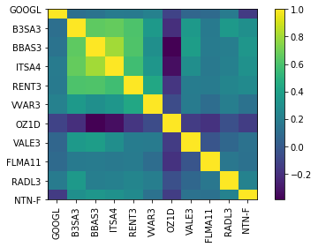

```python
S = risk_models.sample_cov(df)
plotting.plot_covariance(S, plot_correlation=True)
```

Fronteira eficiente e carteira ótima de risco:

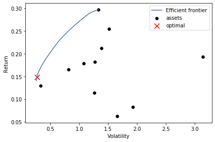

```python
cla = CLA(mu, S)
cla.max_sharpe()
cla.portfolio_performance()
ax = plotting.plot_efficient_frontier(cla)
```

### Quarta etapa

O CAPM é um modelo baseado em suposições sobre comportamentos de investidores, distribuições de risco e retorno, e fundamentos de mercado. Ou seja, o modelo opera a partir do risco dos ativos e do custo de capital. Sua autoria é de William Forsyth Sharpe, Jack Treynor, John Lintner e Jan Mossin, todos baseados no trabalho de Harry Markowitz (vencedor do Prêmio Nobel de Economia de 1990, com Sharpe e Merton Miller) sobre Teoria do Portfólio e diversificação.

Dessa forma, o indicador do Capital Asset Pricing Model é calculado a partir de uma fórmula, que tem como objetivo avaliar se uma ação é valorizada quando seu risco e o valor do dinheiro no tempo são comparados a seu retorno esperado.

Iniciamos importando os dados do índice Bovespa

```python
df_ibov = pd.read_csv("dados/ibov.csv", parse_dates=True, index_col="Data")
df_ibov.head()
```

| Data | IBOV |
| --- | --- |
| 2010-01-01 | 70045.0 |
| 2010-02-01 | 66571.0 |
| 2010-03-01 | 67227.0 |
| 2010-04-01 | 71136.0 |
| 2010-05-01 | 67119.0 |

Repetimos o processo feito na terceira etapa para encontrar a melhor carteira, entre as dez carteiras ótimas de risco calculadas.

```python
max_sharpe = 0
for i in range(1,11):
    path = "dados/grupo" + str(i) + ".csv"
    df = pd.read_csv(path, parse_dates=True, index_col="Data")
    mu = expected_returns.capm_return(df, risk_free_rate = rf, frequency= 12)
    S = risk_models.sample_cov(df)


    # Otimiza melhor Sharpe
    ef = EfficientFrontier(mu, S)
    raw_weights = ef.max_sharpe()
    cleaned_weights = ef.clean_weights()
    retorno = ef.portfolio_performance(risk_free_rate = rf)

    if retorno[2] > max_sharpe:
        max_sharpe = retorno[2]
        port = path
        ef.save_weights_to_file("weights.csv")

print("Sharpe da Carteira Ótima Selecionada: {0}".format(max_sharpe))
print(port)
```

```
Sharpe da Carteira Ótima Selecionada: 0.3547567960747958
dados/grupo2.csv
```

Pesos dos ativos na carteira ótima de risco escolhida, agora utilizando CAPM para estimar os retornos

```python
df_weights = pd.read_csv("weights.csv")
df_weights
```

|  | MELI | 0.08894 |
| --- | --- | --- |
| 0 | AMZN | 0.09042 |
| 1 | APPL | 0.09008 |
| 2 | MSFT | 0.09330 |
| 3 | CRM | 0.09160 |
| 4 | LREN3 | 0.09002 |
| 5 | RENT3 | 0.08940 |
| 6 | VVAR3 | 0.09002 |
| 7 | WEGE3 | 0.09186 |
| 8 | RADL3 | 0.09168 |
| 9 | IBOV | 0.09269 |

Retornos esperados dos ativos da carteira ótima escolhida:

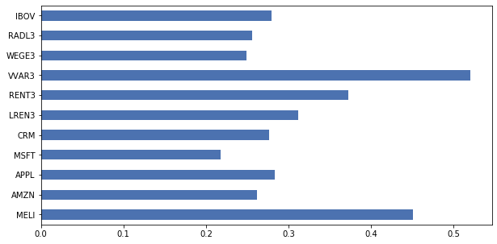

```python
df = pd.read_csv(port, parse_dates=True, index_col="Data")
mu = expected_returns.capm_return(df, risk_free_rate = rf, frequency= 12)
mu.plot.barh(figsize=(10,5));
```

Matriz de covariância dos ativos:

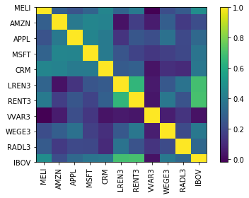

```python
S = risk_models.sample_cov(df)
plotting.plot_covariance(S, plot_correlation=True)
```

Retorno esperado, Risco e Indice de Sharpe da carteira escolhida

```python
ef = EfficientFrontier(mu, S)
raw_weights = ef.max_sharpe()
cleaned_weights = ef.clean_weights()
retorno = ef.portfolio_performance(risk_free_rate = rf, verbose = True)
```

```
Expected annual return: 31.5%
Annual volatility: 82.5%
Sharpe Ratio: 0.35
```

Fronteira eficiente e carteira ótima de risco

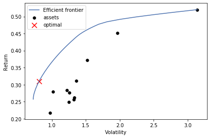

```python
cla = CLA(mu, S)
cla.max_sharpe()
cla.portfolio_performance()
ax = plotting.plot_efficient_frontier(cla)
```

### Quinta etapa

Agora, com a carteira ótima de risco decidida, vamos às alocações para diferentes tipos de investidor. Para isso devemos máximizar a utilidade, dado uma aversão à risco A do investidor. Dependendo do valor de A, a alocação do investidor vai estar entre os dois pontos da reta representada no gráfico abaixo.

```
0.31543092426439107 0.8251594543171841
```

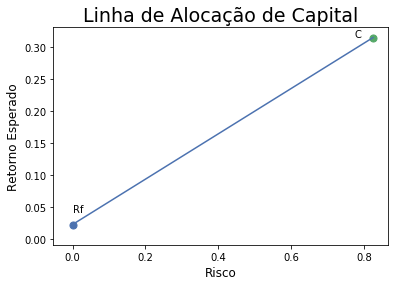

```python
x_values = [0, retorno[1]]
y_values = [rf, retorno[0]]
print(retorno[0], retorno[1])
plt.scatter(0, rf, s=50)
plt.scatter(retorno[1], retorno[0], s=50)
plt.annotate("Rf", (0, rf + 0.02))
plt.annotate("C", (retorno[1] - 0.05, retorno[0]))
plt.title("Linha de Alocação de Capital", fontsize=19)
plt.xlabel("Risco", fontsize=12)
plt.ylabel("Retorno Esperado", fontsize=12)
plt.plot(x_values, y_values)
```

Para um investidor conservador consideramos uma aversão a risco de 8.

```python
a = 8
dpy = retorno[1] ** 2
wy = (retorno[0] - rf)/(a * dpy)
print("Alocação nos Ativos de risco(conservador): {}".format(wy))
```

```
Alocação nos Ativos de risco(conservador): 0.053740642826475817
```

Para um investidor moderado consideramos uma aversão a risco de 2.

```python
a = 2
dpy = retorno[1] ** 2
wy = (retorno[0] - rf)/(a * dpy)
print("Alocação nos Ativos de risco(moderado): {}".format(wy))
```

```
Alocação nos Ativos de risco(moderado): 0.21496257130590327
```

Para um investidor agressivo consideramos uma aversão a risco de 0,3.

```python
a = 0.3
dpy = retorno[1] ** 2
wy = (retorno[0] - rf)/(a * dpy)
print("Alocação nos Ativos de risco(agressivo): {}".format(wy))
```

```
Alocação nos Ativos de risco(agressivo): 1.4330838087060218
```

Vale observar que no caso do investidor agressivo, sua alocação faria com que ele alavancasse seu capital.

### Conclusão e discussão

Após implementado o teorema de Markowitz de dez combinações distintas de ativos, foi definida uma combinação de ativos na qual a carteira ótima de risco apresentaria maior índice Sharpe.

O Índice de Sharpe é um indicador criado por William Sharpe que permite a avaliação relativa entre o risco e o retorno de um determinado investimento. Ele tem o objetivo de mensurar qual é a relação entre o retorno excedente ao ativo livre de risco e sua volatilidade.

Portanto, utilizando o Índice de Sharpe foi definida uma combinação de ativos no qual a carteira ótima de investimentos apresentaria maior retorno em relação ao seu grau de risco.

Essa carteira foi enfim expandida e analisada categóricamente. Assim, a partir de informações sobre as empresas foram elaborados possíveis motivos que definem o peso de cada ativo na carteira.

[figure not shown]

### IBOV: 9,269%

- Alto desempenho
- Risco Brasil, com baixa volatilidade
- Boa oportunidade para investir considerando a taxa de juros em sua mínima histórica.

[figure not shown]

### RADL3: Raia Drogasil 9,168%

- Mercado farmacêutico possuí baixa elasticidade, traz mais segurança.

[figure not shown]

### WEGE3 : WEG S.A 9,186%

- Empresa de produção industrial no mercado de eletricidade, produz motores elétricos, geradores, transformadores.
- Inserida em um mercado com alta perspectiva de crescimento e grande barreira de entrada para novos concorrentes.
- Recentemente iniciou projetos que envolvem inteligência artificial, que também é um mercado de rápido crescimento.

[figure not shown]

### VVAR3: Via Varejo 9,002%

- Inserida no setor de varejo de bens alimentícios. Alto market share no setor que atua.

[figure not shown]

### RENT3: Localiza 8,94%

- Empresa de aluguel de carros, muito consolidada no setor.
- Recentemente foi anunciada uma fusão entre Localiza e Unidas, que deve ser efetivada em não muito tempo.
- As empresas possuem alto grau de sinergia o que deve melhorar a eficiência da operação. Por conta disso há muito espaço para crescimento.

[figure not shown]

#### LREN3: Lojas Renner 9,002%

- Maior loja de departamentos de vestuário do Brasil. Consolidada e líder no setor. Há baixo risco de investimento.

[figure not shown]

### CRM: Sales Force Inc. 9,16%

- Empresa que vende soluções para gerenciamento de empresas, integração de departamentos para melhor atendimento ao cliente e organização, bem como análise de dados.
- Empresa inovadora que possuí boa capacidade de crescimento, principalmente em um ambiente de negócios cada vez mais digital.

[figure not shown]

### MSFT: Microsoft Corporation 9,33%

- Empresa multinacional de tecnologia. O sistema operacional da empresa(Windows) é o mais utilizado no mundo.
- Baixo risco e crescimento estável.

[figure not shown]

### APPL: Apple 9,008%

- Empresa multinacional de tecnologia.
- Produz o Iphone, celular mais vendido no mundo.

[figure not shown]

### AMZN: Amazon 9,042%

- Empresa multinacional de tecnologia, focada em e-commerce.
- Tem alta diversificação de sua atividade, atuando também no ramo de cloud computing, streaming digital e inteligência artificial.
- Rapido crescimento.

[figure not shown]

### MELI: Mercado livre 8,894%

- Maior empresa da América Latina.
- Atua em e-commerce.
- Diversificação para processamento de pagamentos.

## Conclusão

A carteira final selecionada possuí ativos de diversos setores em crescimento rápido, além disso a carteira tem uma diversificação de ativos alta, o que acarreta em uma baixa correlação desses ativos, contribuindo para a diminuição do risco específico de cada setor de atuação. Riscos específicos são aqueles atrelados a uma area de atuação, que impactam somente alguns ativos, enquanto Riscos sistemáticos são aqueles que impactam o Mercado como um todo.

#### Referências e Fontes

Biblioteca PyPortfolioOpt do python

Economática

https://www.sunoresearch.com.br/artigos/capm/

https://www.wrprates.com/teoria-de-markowitz-teoria-da-carteira-e-a-fronteira-eficiente/